# Summarize Results

Chris Moore

5/1/2021

*NOTE: Click ‘Code’ on the right to expand code sections.*

Packages

```r
library(tidyverse)
library(data.table)
library(gtsummary)
library(caret)
library(glmnet)
library(splines)
library(flextable)
```

Custom functions for formatting

```r
fmt_meanse <- function(x, dig=3, fmt = "f", flg="#") {
  paste0(formatC(mean(x), digits=dig, format = fmt, flag=flg),          # mean
         " (", formatC(sd(x), digits=dig, format = fmt, flag=flg), ")") #(SE)
}

factr_lvls <- function(dat) {
  dat %>% mutate(
    Method = factor(mod, levels=c("lso", "lso.sp", "rf"),
                    labels=c("LASSO", "LASSO (sp)", "Random Forest")),
    Event = factor(obs, levels=c("1", "0"), labels=c("Yes", "No")),
    stat = factor(obs, levels=c("1", "0"), labels=c("Sensitivity", "Specificity"))
  ) %>% select(Method, Event, stat, everything(), mod, obs)
}

lab_lso.sp <- as_paragraph("LASSO", as_sub("sp"))             # For flextables
lab_plt <- c("LASSO", bquote("LASSO"["sp"]), "Random Forest") # For plots
```

Variable labels

```r
vrbls <- rbind(AGE_YRS = "Age (years)",
               SEX = "Sex",
               VAX_DOSE_SERIES = "Second vaccine dose",
               VAX_MANU = "Vaccine manufacturer",
               PriorAllergy = "Prior allergy",
               PriorVaxAE = "Prior vaccine adverse event",
               cur_htn = "Prevalent HTN",
               cur_dm = "Prevalent diabetes",
               cur_copd = "Prevalent COPD",
               cur_cancer = "Prevalent cancer",
               cur_hf = "Prevalent heart failure",
               cur_MI = "History of MI",
               cur_ckd = "Prevalent CKD",
               cur_dialysis = "On dialysis",
               cur_stroke = "History of stroke") %>%
  as.data.frame() %>% rownames_to_column("v") %>% rename(lab = V1)
```

## Import data and summarize performance

```r
load("./Outputs/kfold_output/kfold_output_RF.RData")
load("./Outputs/kfold_output/kfold_output_LogLasso.RData")
load("./Outputs/kfold_output/kfold_output_LogLasso_se0.8sp1.2.RData")
```

Separate components of `kfold_cv()` custom function

```r
m_rf <- rf_results$mod_train
p_rf <- rf_results$preds_test
e_rf <- rf_results$perf_test

m_lso <- loglso_results$mod_train
p_lso <- loglso_results$preds_test
e_lso <- loglso_results$perf_test

m_lso.sp <- loglso_results_wtd$mod_train
p_lso.sp <- loglso_results_wtd$preds_test
e_lso.sp <- loglso_results_wtd$perf_test
```

Combine fold-specific errors and summarize performance by class (sensitivity and specificity)

```r
e_all <- rbindlist(list(lso=e_lso, lso.sp=e_lso.sp, rf=e_rf), idcol = "mod") %>%
  factr_lvls()

sens_spec <- e_all %>%
  group_by(mod, obs) %>%
  summarise_at(vars(p_corr=Accuracy, p_incor=Error),
               list(mn = ~mean(.), se = ~sd(.),
                    mnse = ~fmt_meanse(.),
                    p_mnse = ~fmt_meanse(.*100, dig=1))) %>%
  ungroup() %>%
  factr_lvls()
```

Use predictions to also get 2x2 table cell counts

```r
cell_cnts <- rbindlist(list(lso = p_lso[, .(f, obs, pred, correct)],
                            lso.sp = p_lso.sp[, .(f, obs, pred, correct)],
                            rf = p_rf), idcol = "mod") %>%
  .[, .(.N, n_corr=sum(correct), n_incor = .N-sum(correct)),
    by=c("mod","obs")]
```

Use predictions to get overall accuracy

```r
ovral_acc <- rbindlist(list(lso = p_lso[, .(f, obs, pred, correct)],
                            lso.sp = p_lso.sp[, .(f, obs, pred, correct)],
                            rf = p_rf), idcol = "mod") %>%
  .[, .(acc=sum(correct)/.N), by=c("mod", "f")] %>%
  group_by(mod) %>%
  summarise(ovrl_acc = mean(acc), se_ovrlacc = sd(acc),
            Accuracy = fmt_meanse(acc), p_Accuracy = fmt_meanse(acc*100, dig=1))
```

Combine performance summaries

```r
summ_perf <- sens_spec %>%
  left_join(cell_cnts, by=c("mod", "obs")) %>%
  left_join(ovral_acc, by=c("mod"))
```

## Tables

**Table 2:** Sensitivity, specificity, and accuracy

```r
tab2 <- summ_perf %>%
  select(Method, stat, p_corr_mnse, Accuracy) %>%
  pivot_wider(names_from = "stat", values_from = "p_corr_mnse")

(tab2_flx <- flextable(tab2) %>% autofit() %>%
    compose(i=2, j=1, value=lab_lso.sp))
```

| Method | Accuracy | Specificity | Sensitivity |
| --- | --- | --- | --- |
| LASSO | 0.789 (0.019) | 0.804 (0.021) | 0.694 (0.012) |
| LASSOsp | 0.834 (0.013) | 0.867 (0.015) | 0.620 (0.017) |
| Random Forest | 0.884 (0.003) | 0.979 (0.004) | 0.255 (0.022) |

**Table 3:** Sensitivity, specificity, and accuracy

```r
tab3 <- summ_perf %>%
  select(Method, Event, N,
         "N Correct"=n_corr,
         "N Incorrect"=n_incor,
         "% Correct (SE)" = p_corr_p_mnse,
         "% Overall accuracy (SE)"= p_Accuracy)

(tab3_flx <- flextable(tab3) %>% autofit() %>%
    compose(i=3:4, j=1, value=lab_lso.sp) %>%
    align_text_col(align = "right", header = TRUE, footer = TRUE) %>%
    merge_v(j=7) %>% fix_border_issues(part = "all"))
```

| Method | Event | N | N Correct | N Incorrect | % Correct (SE) | % Overall accuracy (SE) |  |
| --- | --- | --- | --- | --- | --- | --- | --- |
| LASSO | No | 26,187 | 21,045 | 5,142 | 80.4 (2.1) | 78.9 (1.9) |  |
| LASSO | Yes | 3,970 | 2,754 | 1,216 | 69.4 (1.2) |  |  |
| LASSOsp | No | 26,187 | 22,703 | 3,484 | 86.7 (1.5) |  | 83.4 (1.3) |
| LASSOsp | Yes | 3,970 | 2,457 | 1,513 | 62.0 (1.7) |  |  |
| Random Forest | No | 26,187 | 25,638 | 549 | 97.9 (0.4) | 88.4 (0.3) |  |
| Random Forest | Yes | 3,970 | 1,014 | 2,956 | 25.5 (2.2) |  |  |

**Table 4:** Average and fold-specific variable importance in the random forest

```r
# Get values in wide format ##$
var_imprt <- lapply(m_rf, function(x) {
  rownames_to_column(varImp(x)[["importance"]],"vrbl")
}) %>%
  rbindlist(idcol="fold")

tab4 <- var_imprt %>%
  pivot_wider(names_from = "fold", values_from = "Overall") %>%
  mutate(vrbl2 = case_when( grepl("SEX", vrbl) ~ "SEX",
                            grepl("VAX_DOSE", vrbl) ~ "VAX_DOSE_SERIES",
                            grepl("VAX_MANU", vrbl) ~ "VAX_MANU",
                            TRUE ~ gsub("1", "", vrbl)),
         vrbl2 = factor(vrbl2, levels=vrbls$v, label=vrbls$lab)) %>%
  group_by(Predictor = vrbl2) %>%
  summarise_if(is.numeric, sum) %>% ungroup() %>% ungroup() %>%
  rowwise() %>%
  mutate(`Mean (SE)` = fmt_meanse(c_across(fold1:fold5), dig=2),
         avg = mean(c_across(fold1:fold5))) %>%
  rename_with(~ gsub("fold", "Fold ", .)) %>%
  arrange(-avg) %>% select(Predictor, `Mean (SE)`, everything())

(tab4_flx <- flextable(select(tab4, -avg)) %>%
  autofit())
```

| Predictor | Mean (SE) | Fold 1 | Fold 2 | Fold 3 | Fold 4 | Fold 5 |
| --- | --- | --- | --- | --- | --- | --- |
| Age (years) | 100.00 (0.00) | 100.00 | 100.00 | 100.00 | 100.00 | 100.00 |
| Sex | 12.45 (0.87) | 13.86 | 12.31 | 12.46 | 12.11 | 11.52 |
| Vaccine manufacturer | 12.23 (0.35) | 11.98 | 12.50 | 12.16 | 12.67 | 11.84 |
| Second vaccine dose | 9.17 (0.74) | 9.50 | 8.59 | 9.60 | 9.96 | 8.21 |
| Prior allergy | 4.29 (0.59) | 3.79 | 4.96 | 3.82 | 3.97 | 4.91 |
| Prevalent HTN | 2.85 (0.35) | 3.17 | 2.51 | 3.28 | 2.74 | 2.57 |
| Prevalent diabetes | 2.64 (0.25) | 2.35 | 2.53 | 3.03 | 2.68 | 2.64 |
| Prior vaccine adverse event | 1.82 (0.47) | 1.55 | 2.27 | 1.42 | 1.48 | 2.39 |
| Prevalent COPD | 1.82 (0.29) | 1.76 | 1.69 | 2.30 | 1.80 | 1.53 |
| Prevalent heart failure | 1.80 (0.32) | 2.11 | 1.49 | 2.06 | 1.92 | 1.43 |
| Prevalent cancer | 1.36 (0.27) | 1.16 | 1.72 | 1.13 | 1.23 | 1.59 |
| On dialysis | 0.84 (0.13) | 0.95 | 0.77 | 0.89 | 0.95 | 0.64 |
| Prevalent CKD | 0.55 (0.13) | 0.62 | 0.34 | 0.69 | 0.55 | 0.53 |
| History of stroke | 0.45 (0.11) | 0.37 | 0.40 | 0.44 | 0.65 | 0.41 |
| History of MI | 0.00 (0.00) | 0.00 | 0.00 | 0.00 | 0.00 | 0.00 |

## Figures

**Figure 1:** Mean (standard error) LASSO and random forest predictive performance during five-fold cross-validation

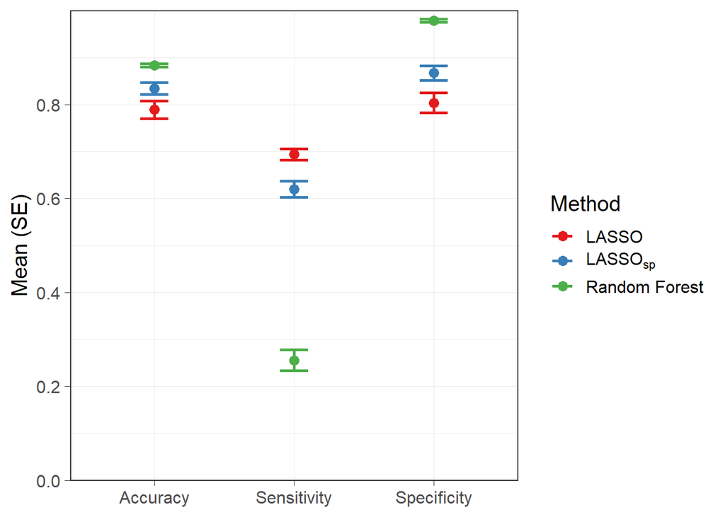

```r
fig1 <- summ_perf %>%
  select(Method, stat, mn=p_corr_mn, se=p_corr_se,
         mn_Accuracy=ovrl_acc, se_Accuracy=se_ovrlacc) %>%
  pivot_wider(names_from = "stat", values_from = c("mn", "se")) %>%
  pivot_longer(cols=-Method) %>%
  separate(name, into=c("mnse", "stat"), sep="_") %>%
  pivot_wider(names_from = "mnse") %>%
  ggplot(aes(x=stat, y=mn, color=Method)) +
  geom_point(size=3) +
  geom_errorbar(aes(ymin=mn-se, ymax=mn+se), size=1, width=0.2) +
  scale_y_continuous("Mean (SE)", limits=c(0, 1), breaks=seq(0, 0.8, 0.2), expand=c(0,0)) +
  xlab(NULL) +
  scale_color_brewer(palette = "Set1", labels=lab_plt) +
  theme_bw(base_size = 15, base_line_size=0.3)
fig1
```

**Figure 2:** LASSO predicted probabilities by observed event status. Dashed line represents average threshold selected for predicting an event from ROC analyses

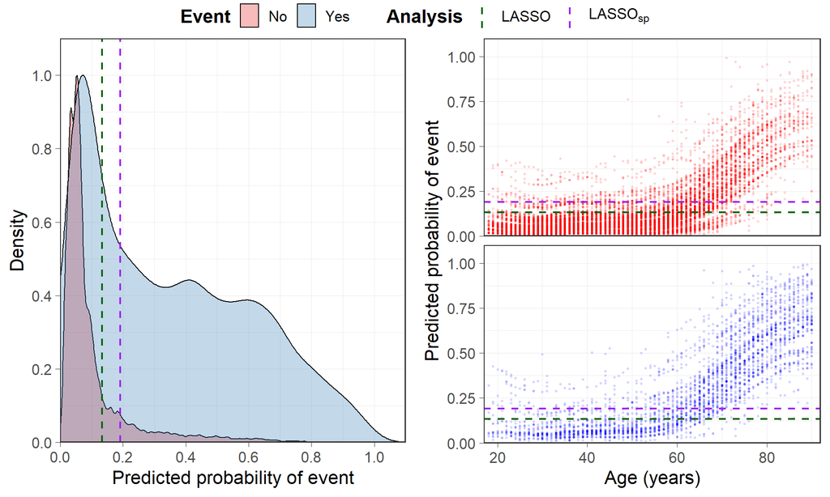

```r
## Re-create fold data ##$##$
source("./R/setup_data.R")
set.seed(12) # same seed as used before
folds <- createFolds(y=unlist(dat[, event_asnum]), k=5)

d_fold <- lapply(folds, function(f) {
  dat[f]
}) %>% rbindlist(idcol="fold")

## Combine with predictions ##$##$
preds <- cbind(d_fold, p_lso)
preds[, Event := factor(obs, levels=c("0", "1"), labels=c("No", "Yes"))]
# Check that data lines up (observerd outcomes should match)
# sum(preds$SeriousEvent != preds$obs)
##$##$##$##$##$##$



# Average prob threshold from ROC ##$##$
p_thresh = data.frame(
  Analysis = c("LASSO", "LASSO (sp)"),
  Threshold = c(mean(sapply(m_lso, `[[`, "p_thresh")), mean(sapply(m_lso.sp, `[[`, "p_thresh")))
)
##$##$##$##$##$##$



## Plot prob densities by event ##$##$
p1 <- ggplot(preds, aes(x=pred_raw)) +
  geom_density(aes(y=..scaled.., fill=Event, group=Event), alpha=0.3) +
  geom_vline(data=p_thresh, aes(xintercept=Threshold, color=Analysis),
             size=0.72, linetype="dashed") +
  scale_y_continuous("Density", limits = c(0, 1.1),
                     breaks = seq(0, 1, 0.2), expand=c(0,0)) +
  scale_x_continuous("Predicted probability of event", limits = c(0, 1.1),
                     breaks = seq(0, 1, 0.2), expand=c(0,0)) +
  scale_fill_brewer(palette = "Set1") +
  scale_color_manual(values=c("darkgreen", "purple"), labels=lab_plt[1:2]) +

  guides(linetype = guide_legend(override.aes = list(size = 0.9))) +
  theme_bw(base_size = 16, base_line_size=0) +
  theme(legend.box.margin = margin(t=-5, b=-7),
        legend.key.height = unit(1.5, "line"),
        legend.title = element_text(face="bold"))

## Plot probs vs age by event ##$##$
p2 <- ggplot(preds[AGE_YRS<quantile(AGE_YRS,0.99)], # Trim at 99th percentile
             aes(y=pred_raw, x=AGE_YRS, color=Event)) +
  geom_point(alpha=0.13, size=0.6) +
  geom_hline(data=p_thresh, aes(yintercept=Threshold, color=Analysis), size=0.76, linetype="dashed") +
  facet_wrap(.~Event, ncol=1) +
  scale_x_continuous("Age (years)", limits = c(17, 92),
                     breaks = seq(20, 90, 20), expand=c(0,0)) +
  scale_y_continuous("Predicted probability of event", limits = c(0, 1.1),
                     breaks = seq(0, 1, 0.25), expand=c(0,0)) +
  scale_color_manual(values=c("darkgreen", "purple", "red", "blue")) +
  # scale_color_brewer(palette = "Set1") +
  scale_linetype_manual(values=c("dashed", "twodash")) +
  theme_bw(base_size = 16, base_line_size=0.3) +
  theme(strip.text = element_blank(),
        strip.background = element_blank())
##$##$##$##$##$##$



## Combine ##$##$
fig2 <- ggpubr::ggarrange(p1, p2, ncol=2, common.legend = TRUE)
fig2
```

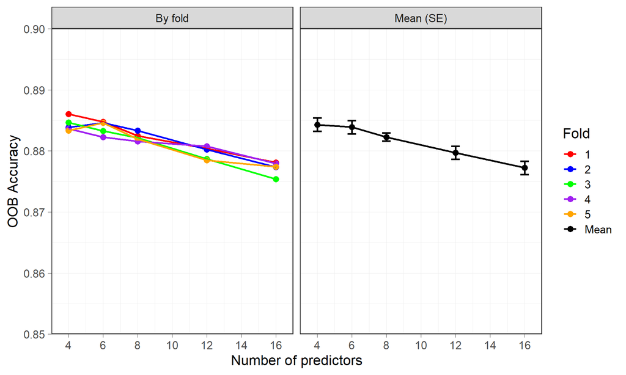

```r
npreds_rf <-  lapply(m_rf, `[[`, "results") %>%
  rbindlist(idcol="Fold") %>%
  mutate(Fold = gsub("fold", "", Fold))

fig3 <- npreds_rf %>%
  mutate(se=NA, categ="By fold") %>%
  rbind(npreds_rf %>%
          group_by(mtry) %>%
          summarise(categ = "Mean (SE)", Fold="Mean", se = sd(Accuracy),
                    Accuracy = mean(Accuracy), Kappa = mean(Kappa))) %>%
  ggplot(aes(x=mtry, y=Accuracy, color=Fold)) +
  geom_point(size=3) +
  geom_line(size=1) +
  geom_errorbar(aes(ymin=Accuracy-se, ymax=Accuracy+se), size=1, width=0.5) +
  facet_grid(. ~ categ) +
  scale_y_continuous("OOB Accuracy", limits = c(0.85, 0.90),
                     breaks = seq(0.85, 0.9, 0.01), expand=c(0,0)) +
  scale_x_continuous("Number of predictors", limits = c(3, 17),
                     breaks = seq(4, 16, 2), expand=c(0,0)) +
  scale_color_manual(values=c("red", "blue", "green", "purple", "orange", "black")) +
  theme_bw(base_size = 16, base_line_size=0.3)
fig3
```

**Figure 4:** Random forest variable importance averaged over folds

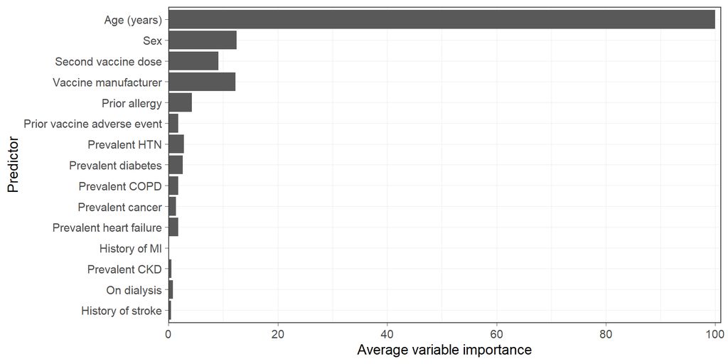

```r
fig4 <- ggplot(tab4, aes(x = Predictor, y=avg)) +
  geom_bar(stat="identity") +
  scale_y_continuous("Average variable importance", limits = c(0, 101),
                     breaks = seq(0, 100, 20), expand=c(0,0)) +
  scale_x_discrete(limits=rev) +
  scale_color_brewer(palette = "Set1") +
  coord_flip() +
  theme_bw(base_size = 14, base_line_size=0.3)
fig4
```

## Save

```r
fpath <- "./Outputs/Final_Results/"

# Tables ##$
tbls <- paste0("tab", 2:4)
walk(paste0(tbls, "_flx"), ~ save_as_docx(get(.x), path=paste0(fpath, .x, ".docx")))
walk(tbls, ~ fwrite(get(.x), paste0(fpath, .x, ".csv")))

# Figures ##$
figs <- paste0("fig", 1:4)# ht x width      ht x width
fig_params <- list(fig1 = c(NA,NA), fig2 = c(10, 6),
                   fig3 = c(10, 6), fig4 = c(10.5,6))
walk(figs, ~ ggsave(
  plot=get(.x), filename=paste0(fpath, .x, ".jpeg"), units="in",
  width = fig_params[[.x]][[1]], height = fig_params[[.x]][[2]]
  ) )
```

## Appendix

These additional results about the final models are only for reference and are not formatted for presentation

#### LASSO models

```r
lasso_coef <- lapply(m_lso, function(x) {
  tmp <- coef(x, s = "lambda.min")
  data.frame(name = tmp@Dimnames[[1]][tmp@i + 1],
             coefficient = tmp@x)
} )


lasso_models <- data.frame(
  f = names(m_lso),
  lambda = sapply(m_lso, `[[`, "lambda.min"),
  n_terms = c(sapply(lasso_coef, nrow)),
  age_frmla = as.character(sapply(m_lso, `[[`, "cust_tune")),
  p_thresh = sapply(m_lso, `[[`, "p_thresh"),
  p_thresh.sp =  sapply(m_lso.sp, `[[`, "p_thresh"),
  row.names = NULL
) %>% mutate(age_frmla = gsub(")\\^2", "", gsub(".*\\+", "", age_frmla)))

lasso_models
```

```
##       f       lambda n_terms                        age_frmla  p_thresh
## 1 fold1 0.0004657620      61  bs(AGE_YRS, df = 6, degree = 2) 0.1273416
## 2 fold2 0.0006327313      58  bs(AGE_YRS, df = 6, degree = 2) 0.1482545
## 3 fold3 0.0005429170      53  bs(AGE_YRS, df = 5, degree = 2) 0.1209304
## 4 fold4 0.0005487032      59  bs(AGE_YRS, df = 8, degree = 4) 0.1289101
## 5 fold5 0.0005081813      59  bs(AGE_YRS, df = 6, degree = 2) 0.1418237
##   p_thresh.sp
## 1   0.1862987
## 2   0.1825527
## 3   0.2000997
## 4   0.1873445
## 5   0.1986860
```

#### Random forest tune parameters

```r
rf_tuneparams <- lapply(m_rf, function(x) {
  data.frame(n_tree = x[["finalModel"]][["ntree"]],
             n_vrbls = x[["finalModel"]][["mtry"]])
}) %>% rbindlist(idcol="fold")

rf_tuneparams
```

```
##     fold n_tree n_vrbls
## 1: fold1    500       4
## 2: fold2    750       6
## 3: fold3    500       4
## 4: fold4    250       4
## 5: fold5    500       6
```